# ConvergenceP

August 22, 2014

## Convergence in Probability

The **ConvergenceP** shiny application ilustrates the convergence in probability of the sample mean to its true value for three distribution functions: normal, exponential and lognormal distributions.

To illustrate this convergence the shinyapp controls the sample size \(n\), the radius of the neighborhood \(\epsilon\), the number of simulation and the distribution of the population. Furthermore, to ilustrate how the averages approches the true value, a cumulative average of the sample is plotted.

## Parameters of the simulation

1. **Probability density function.** To make a fair comparison the three distributions selected have the same mean and standard deviation.

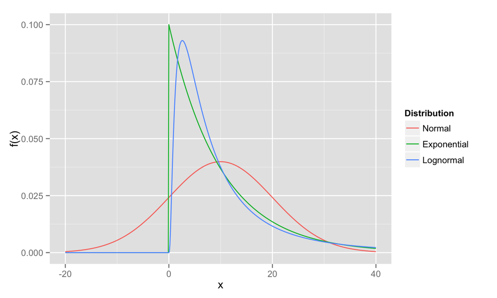

## Parameters of the simulation (cont.)

1. **Sample size \(n\).** Increase or decrease the sample size to visualize how the lines get closer to the horizontal line at 10.
2. **Number of simulation \(N\).** When you increase the value you will get more lines in the plot. Most of them should get closer to the horizontal line at 10.
3. **Error size \(\epsilon\).** When you decrease this value, more line should turn in red, because it would be less likely to get closer to the horizontal line at 10.

## Simulated limit

The limit tab of the ConvergenceP shinyapp shows the final mean for each simulated simulation. For example if we simulate 5 series of length \(n = 1000\), the output would be.

```r
tseries <- ts(apply(matrix(rnorm(1000*5, mean=10, sd=10),
                nrow = 1000, ncol = 5), 2,cumsum)/seq(1,1000))
table <- as.data.frame(tseries[1000,])
names(table) <- ""
print(table)
```

```
##
## Series 1 10.260
## Series 2 10.082
## Series 3  9.854
## Series 4  9.950
## Series 5  9.826
```